# Reproducible Research - Assignment 1

## Task 1 - Load the data & plot the histogram of the total number of steps taken each day

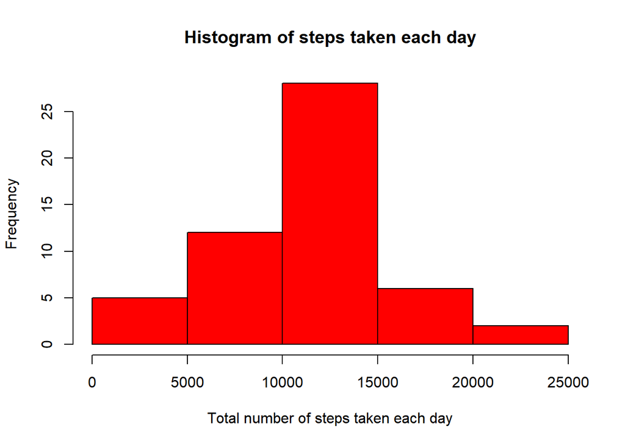

```r
setwd("C:/Users/Siddharth/Documents/Careers/Siddharth/DataScienceSpecialization/Reproducible Research/Week 2/")

activity <- read.csv("activity.csv")
activity <- na.omit(activity)

total_steps <- tapply(activity$steps, activity$date, sum)

total_steps <- total_steps[!is.na(total_steps)]

hist(total_steps, col = "red", xlab = "Total number of steps taken each day", main = "Histogram of steps taken each day")
```

```r
mean_total_steps <- as.integer(mean (total_steps))

median_total_steps <- median (total_steps)
```

The mean for the number of steps taken each day is 10766

The median for the number of steps taken each day is 10765

## Task 2 - Find the average daily pattern

Calculate the average number of steps taken for each time interval across all the days

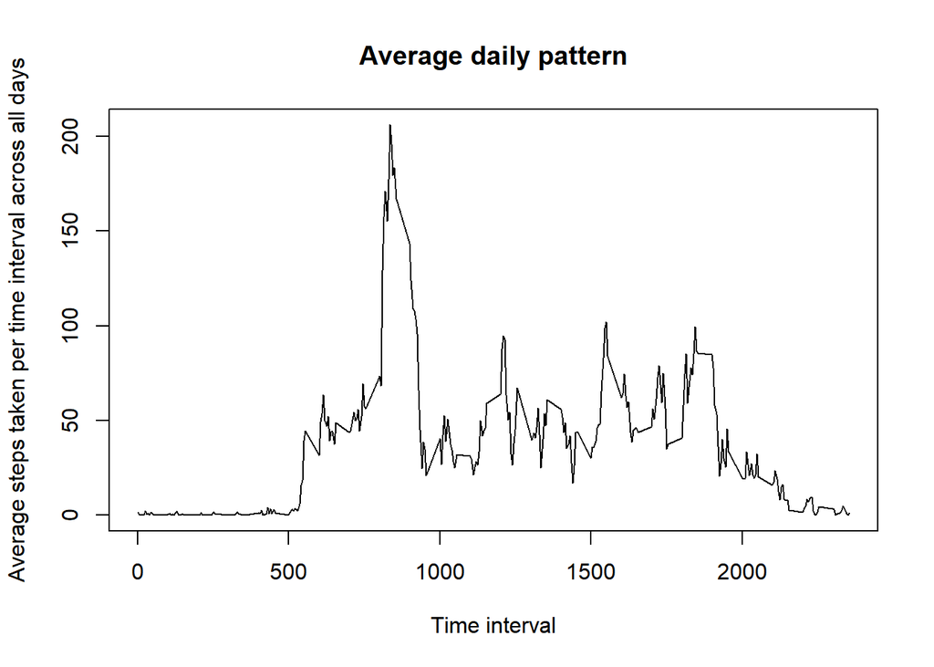

```r
mean_steps <- tapply(activity$steps, activity$interval, mean)

mean_steps_df <- data.frame(mean_steps)

mean_steps_df2 <- cbind(mean_steps_df, activity$interval[1:288])

plot(mean_steps_df2$`activity$interval[1:288]`, mean_steps_df2$mean_steps, type = "l", xlab = "Time interval", ylab = "Average steps taken per time interval across all days", main = "Average daily pattern")
```

```r
max_steps <- as.integer(max(mean_steps))
```

The maximum number of steps on average occurs at the 835th time interval and it is 206

## Task 3 - Imputing missing values

Calculate the total number of missing values (NAs)

```r
activity <- read.csv("activity.csv")

activity_na_count <- activity[rowSums(is.na(activity)),]

nos_na <- nrow(activity_na_count)
```

The total number of missing values in the dataset is 2304

Apply a strategy to replace missing values - replace missing values with the mean for that time interval

```r
library(dplyr)
```

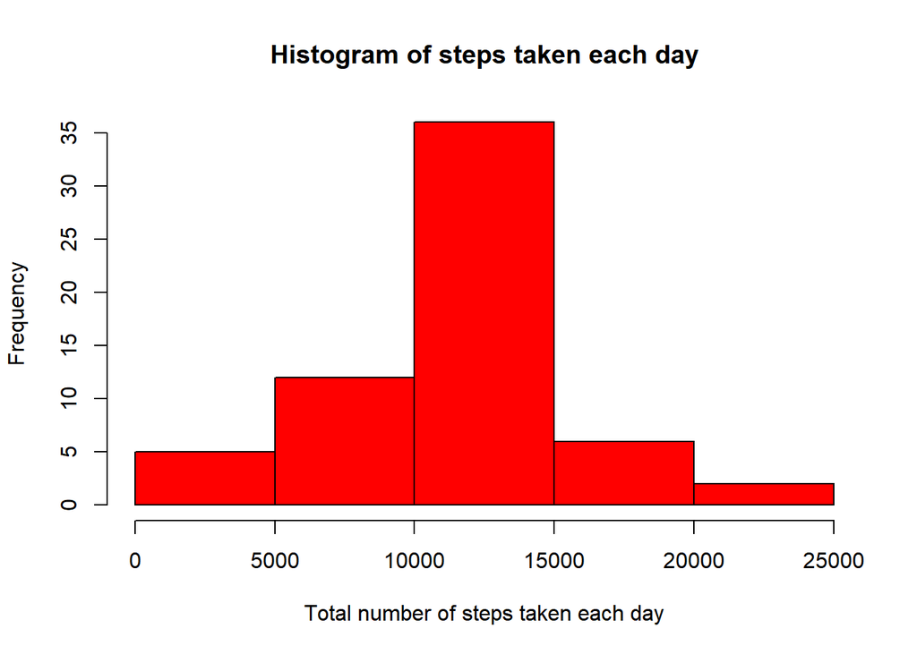

```r
mean_steps_df2 <-  mean_steps_df2 %>% rename(interval = `activity$interval[1:288]`)

activity <- read.csv("activity.csv")

for (i in 1: 17568){
        if (is.na(activity$steps[i] == TRUE)){
                interval <- activity$interval[i]
                activity$steps[i] <- mean_steps_df2$mean_steps[match(interval, mean_steps_df2$interval)]
        }
        i <- i + 1

}

total_steps_nona <- tapply(activity$steps, activity$date, sum)

total_steps_nona <- total_steps_nona[!is.na(total_steps)]

hist(total_steps_nona, col = "red", xlab = "Total number of steps taken each day", main = "Histogram of steps taken each day")
```

```r
mean_total_steps_nona <- as.integer(mean (total_steps_nona))

median_total_steps_nona <- as.integer(median (total_steps_nona))
```

The mean for the number of steps taken each day with NAs removed is 10766

The median for the number of steps taken each day with NAs removed is 10766

These values **DO NOT** differ from the estimates of the mean and median in the first part

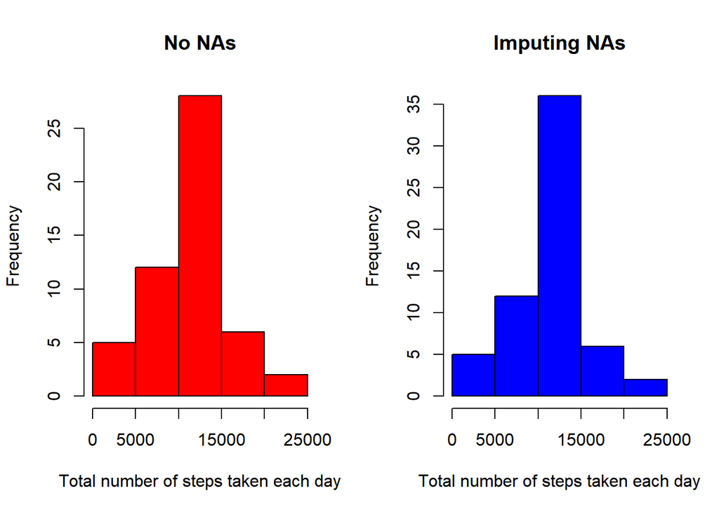

```r
par(mfrow = c(1,2))

hist(total_steps, col = "red", xlab = "Total number of steps taken each day", main = "No NAs")

hist(total_steps_nona, col = "blue", xlab = "Total number of steps taken each day", main = "Imputing NAs")
```

It can be seen from the graphs above that imputing NAs bumps up the frequency for the number of steps in the 10,000-15,000 range but the overall pattern remains the same

## Task 4 - Differences in activity patterns between weekdays and weekends

```r
library(lubridate)
```

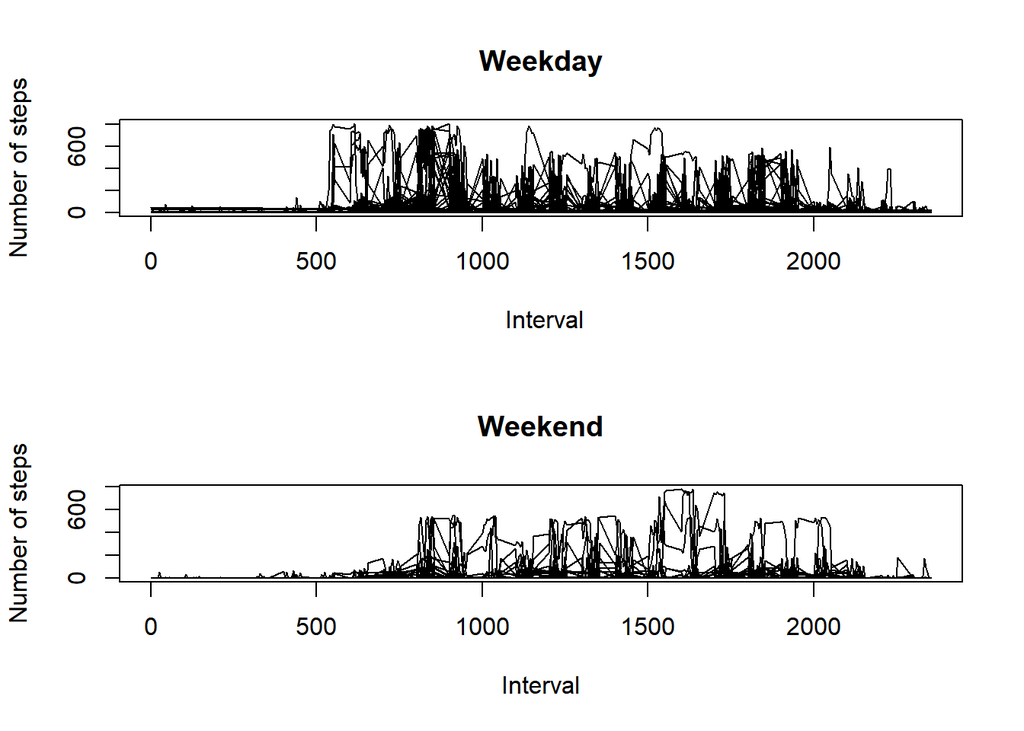

```r
activity$date <-  ymd(activity$date)

activity$day <- weekdays(activity$date, abbreviate = TRUE)

activity$day_type <- ifelse(weekdays(activity$date) %in% c("Saturday", "Sunday"), "weekend", "weekday")

activity_wekd <- activity %>% filter(day_type == "weekday")

activity_wekend <- activity %>% filter(day_type == "weekend")

par(mfrow = c(2,1))

plot(activity_wekd$interval,activity_wekd$steps, type = "l", xlab = " Interval", ylab = "Number of steps", main = "Weekday")

plot(activity_wekend$interval, activity_wekend$steps, type = "l", xlab = "Interval", ylab = "Number of steps", main = "Weekend")
```